# Corrección grifos duplicados

```r
library(lubridate)
library(stringr)
suppressMessages(library(tidyverse))
prices <- readRDS(here::here("data","processed","data_2005_2018_clean.rds"))
grifos <- readRDS(here::here("data","processed","grifo_coding_raw.rds"))
'%ni%' <- Negate('%in%')
```

Corregerimos los grifos duplicados, ayudandonos con la data de precios y la data geolocalizada.

Primero, todos los grifos que tienen mismo código, más de una entrada, y que no sean de un grifo conocido, esos los trataremos de manera independiente.

```r
grifos_repetidos <- grifos %>%
    filter(!is.na(lat),
           !str_detect(razon_social,"COESTI"),
           !str_detect(razon_social,"REPSOL"),
           !str_detect(razon_social,"PERUANA DE COMB")) %>%
    group_by(codigo_de_osinergmin) %>%
    filter(n()>1) %>%
    ungroup() %>%
    arrange(lat,codigo_de_osinergmin) %>%
    distinct(codigo_de_osinergmin, .keep_all = TRUE)

grifos_sin_marca_repetidos <- grifos %>%
    filter(!is.na(lat),
           !str_detect(razon_social,"COESTI"),
           !str_detect(razon_social,"REPSOL"),
           !str_detect(razon_social,"PERUANA DE COMB")) %>%
    group_by(codigo_de_osinergmin) %>%
    filter(n()>1) %>%
    ungroup()

grifos_1 <- anti_join(grifos,
                      grifos_sin_marca_repetidos,
                      by = NULL) %>%
    bind_rows(grifos_repetidos)
```

Ahora, `grifos_1` ya no tiene duplicados con el mismo código, al menos para casos sin grifos conocidos. Como hay grifos de PECSA que podrían haber pasado a COESTI, los filtramos y solo vemos duplicados que tengan que ver con Repsol. En caso duplicado, nos quedamos siempre con la razón social de Repsol:

```r
grifos_repsol_depurado <- grifos_1 %>%
    filter(!is.na(lat),
           !str_detect(razon_social,"COESTI"),
           !str_detect(razon_social,"PERUANA DE COMB")) %>%
    group_by(codigo_de_osinergmin) %>%
    filter(n() > 1) %>%
    ungroup() %>%
    arrange(codigo_de_osinergmin) %>%
    filter(str_detect(razon_social, "REPSOL")) %>%
    distinct(codigo_de_osinergmin, .keep_all = TRUE)

#filtramos todas las observaciones que
grifos_repsol_repetidos <- grifos_1 %>%
    filter(!is.na(lat),
           !str_detect(razon_social,"COESTI"),
           !str_detect(razon_social,"PERUANA DE COMB")) %>%
    group_by(codigo_de_osinergmin) %>%
    filter(n() > 1) %>%
    ungroup() %>%
    arrange(codigo_de_osinergmin)

grifos_2 <- anti_join(grifos_1,
                      grifos_repsol_repetidos,
                      by = NULL) %>%
    bind_rows(grifos_repsol_depurado)
```

Ahora debería haber menos grifos repetidos, verificamos:

```r
grifos_coesti_depurado <- grifos_2 %>%
    filter(!is.na(lat)) %>%
    group_by(codigo_de_osinergmin) %>%
    filter(n()>1) %>%
    ungroup() %>%
    arrange(codigo_de_osinergmin) %>%
    distinct(codigo_de_osinergmin, .keep_all = TRUE)

grifos_coesti_repetido <- grifos_2 %>%
    filter(!is.na(lat)) %>%
    group_by(codigo_de_osinergmin) %>%
    filter(n()>1) %>%
    ungroup() %>%
    arrange(codigo_de_osinergmin)

grifos_3 <- anti_join(grifos_2,
                      grifos_coesti_repetido,
                      by = NULL) %>%
    bind_rows(grifos_coesti_depurado)
```

```r
grifos_3 %>%
    filter(!is.na(lat)) %>%
    group_by(codigo_de_osinergmin) %>%
    filter(n()>1)
```

| codificador | codigo_de_osinergmin | razon_social | ruc | direccion | distrito | n | orden_original | bandera | glp | gnv | llanteria | islas_comb_liq | mecanico | aceite | lavado | tienda | cajero | en_avenida_principal | lat | lon | revisar |
| --- | --- | --- | --- | --- | --- | --- | --- | --- | --- | --- | --- | --- | --- | --- | --- | --- | --- | --- | --- | --- | --- |

Ahora ya no hay duplicados por `codigo_de_osinerming` en la base de datos.

## Verificamos por dirección duplicada

```r
grifos_3 %>%
    filter(!is.na(lat)) %>%
    group_by(direccion) %>%
    filter(n()>1)
```

| codificador | codigo_de_osinergmin | razon_social | ruc | direccion | distrito | n | orden_original | bandera | glp | gnv | llanteria | islas_comb_liq | mecanico | aceite | lavado | tienda | cajero | en_avenida_principal | lat | lon | revisar |
| --- | --- | --- | --- | --- | --- | --- | --- | --- | --- | --- | --- | --- | --- | --- | --- | --- | --- | --- | --- | --- | --- |
| DUC | 6764 | COESTI S.A. | 20127765279 | AV. PASEO DE LA REPUBLICA N° 5790-5798 | MIRAFLORES | 1345 | 21 | Primax | 0 | 0 | 0 | 8 | 0 | 0 | 1 | 1 | 1 | 1 | -12.12350 | -77.02417 | NA |
| DUC | 8009 | PERUANA DE ESTACIONES DE SERVICIOS S.A.C. | 20330033313 | AV. PASEO DE LA REPUBLICA N° 5790-5798 | MIRAFLORES | 1993 | 158 | Pecsa | 2 | 0 | 0 | 4 | 0 | 0 | 0 | 1 | 1 | 1 | -12.12346 | -77.02496 | NA |

OK, son grifos distintos, de un lado al otro de la avenida.

En adición, los grifos 83435 y 137688 son los mismos (compra de Repsol, dir AV. BAUZATE Y MEZA N° 1050). Nos quedamos con 137688

```r
grifos_4 <- grifos_3 %>%
    filter(codigo_de_osinergmin != 83435)

prices_1 <- prices %>%
    mutate(codigo_de_osinergmin = as.numeric(codigo_de_osinergmin),
           codigo_de_osinergmin = if_else(codigo_de_osinergmin == 83435,
                                          137688,
                                          codigo_de_osinergmin))
```

## Verificamos que no hay grifos con las mismas coordenadas

```r
grifos_4 %>%
    filter(!is.na(lat)) %>%
    group_by(lat, lon) %>%
    filter(n()>1) %>%
    arrange(lat, lon) %>%
    ungroup() %>%
    select(codigo_de_osinergmin, razon_social, direccion, distrito, bandera)
```

| codigo_de_osinergmin | razon_social | direccion | distrito | bandera |
| --- | --- | --- | --- | --- |
| 37795 | IMPORTACIONES EXPORTACIONES SAN LUIS S.A. | AV. NICOLAS ARRIOLA N° 2140 ESQ. CON AV. SAN LUIS | SAN LUIS | Repsol |
| 132204 | REPSOL COMERCIAL S.A.C. | AV. NICOLAS ARRIOLA N° 2140 ESQUINA CON AV. SAN LUIS | SAN LUIS | Repsol |
| 9630 | DELTA COMBUSTIBLES E.I.R.L. | AV. ALFREDO MENDIOLA N° 700 ¿ 704 | SAN MARTIN DE PORRES | PETROPERU |
| 128675 | DELTA CHOCAS E.I.R.L. | ALFREDO MENDIOLA 700 - 704 URB. PALAO | SAN MARTIN DE PORRES | PETROPERU |

Debemos tener cuidado con estos, y corregir la base de datos de precios, solo en este caso es necesario, (eliminaremos codigos de osinerming en grifos que son iguales.)

Los grifos 37795 y 132204 en realidad son los mismos (compra de Repsol). Por tanto, con quedamos con el código de Repsol y cambiamos en al base de datos de precios el código 37795 por 132204.

[output not shown]

Los grifos 9630 y 128675 en realidad son los mismos cambian de razón social. Nos quedamos con Delta Chocas (128675), por ser el nombre más reciente:

```r
prices_2 %>%
    filter(codigo_de_osinergmin == 9630)
```

| codigo_de_osinergmin | razon_social | ruc | departamento | provincia | distrito | direccion | fecha_hora | producto | precio_de_venta | unidad |
| --- | --- | --- | --- | --- | --- | --- | --- | --- | --- | --- |
| 9630 | DELTA COMBUSTIBLES E.I.R.L. | 20524016070 | LIMA | LIMA | SAN MARTIN DE PORRES | AV. ALFREDO MENDIOLA N° 700 ¿ 704 | 2007-05-01 06:46:24 | DIESEL | 10.25 | Soles/Galón |
| 9630 | DELTA COMBUSTIBLES E.I.R.L. | 20524016070 | LIMA | LIMA | SAN MARTIN DE PORRES | AV. ALFREDO MENDIOLA N° 700 ¿ 704 | 2007-05-01 06:46:24 | G84 | 10.79 | Soles/Galón |
| 9630 | DELTA COMBUSTIBLES E.I.R.L. | 20524016070 | LIMA | LIMA | SAN MARTIN DE PORRES | AV. ALFREDO MENDIOLA N° 700 ¿ 704 | 2007-05-01 06:46:24 | G90 | 12.55 | Soles/Galón |
| 9630 | DELTA COMBUSTIBLES E.I.R.L. | 20524016070 | LIMA | LIMA | SAN MARTIN DE PORRES | AV. ALFREDO MENDIOLA N° 700 ¿ 704 | 2007-05-07 18:34:51 | DIESEL | 10.25 | Soles/Galón |
| 9630 | DELTA COMBUSTIBLES E.I.R.L. | 20524016070 | LIMA | LIMA | SAN MARTIN DE PORRES | AV. ALFREDO MENDIOLA N° 700 ¿ 704 | 2007-05-07 18:34:51 | G84 | 10.79 | Soles/Galón |
| 9630 | DELTA COMBUSTIBLES E.I.R.L. | 20524016070 | LIMA | LIMA | SAN MARTIN DE PORRES | AV. ALFREDO MENDIOLA N° 700 ¿ 704 | 2007-05-07 18:34:51 | G90 | 12.55 | Soles/Galón |
| 9630 | DELTA COMBUSTIBLES E.I.R.L. | 20524016070 | LIMA | LIMA | SAN MARTIN DE PORRES | AV. ALFREDO MENDIOLA N° 700 ¿ 704 | 2007-05-07 18:35:46 | DIESEL | 10.25 | Soles/Galón |
| 9630 | DELTA COMBUSTIBLES E.I.R.L. | 20524016070 | LIMA | LIMA | SAN MARTIN DE PORRES | AV. ALFREDO MENDIOLA N° 700 ¿ 704 | 2007-05-07 18:35:46 | G84 | 10.79 | Soles/Galón |
| 9630 | DELTA COMBUSTIBLES E.I.R.L. | 20524016070 | LIMA | LIMA | SAN MARTIN DE PORRES | AV. ALFREDO MENDIOLA N° 700 ¿ 704 | 2007-05-07 18:35:46 | G90 | 12.55 | Soles/Galón |
| 9630 | DELTA COMBUSTIBLES E.I.R.L. | 20524016070 | LIMA | LIMA | SAN MARTIN DE PORRES | AV. ALFREDO MENDIOLA N° 700 ¿ 704 | 2007-05-31 22:19:34 | DIESEL | 10.61 | Soles/Galón |

[output cut: 990 more lines]

```r
prices_3 <- prices_2 %>%
    mutate(codigo_de_osinergmin = as.numeric(codigo_de_osinergmin),
           codigo_de_osinergmin = if_else(codigo_de_osinergmin == 9630,
                                          128675,
                                          codigo_de_osinergmin))

prices_3 %>%
    filter(codigo_de_osinergmin == 9630)
```

| codigo_de_osinergmin | razon_social | ruc | departamento | provincia | distrito | direccion | fecha_hora | producto | precio_de_venta | unidad |
| --- | --- | --- | --- | --- | --- | --- | --- | --- | --- | --- |

```r
#eliminamos de grifos:

grifos_6 <- grifos_5 %>%
    filter(codigo_de_osinergmin != 9630)

grifos_6 %>%
    filter(!is.na(lat)) %>%
    group_by(lat, lon) %>%
    filter(n()>1) %>%
    arrange(lat, lon) %>%
    ungroup() %>%
    select(codigo_de_osinergmin, razon_social, direccion, distrito, bandera)
```

| codigo_de_osinergmin | razon_social | direccion | distrito | bandera |
| --- | --- | --- | --- | --- |

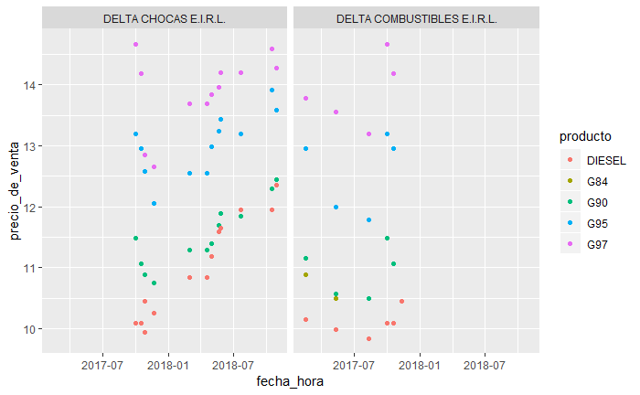

```r
prices %>%
    filter(codigo_de_osinergmin %in% c(9630,128675),
           year(fecha_hora) >= 2017) %>%
    ggplot2::ggplot(aes(x = fecha_hora, y = precio_de_venta, color = producto)) +
    ggplot2::geom_point() +
    ggplot2::facet_wrap(~razon_social)
```

## Verificamos que no hay grifos evidentemente mal codificados con respecto a bandera

Verifiquemso que todos los grifos de Repsol estén bien codificados:

```r
grifos_6 %>%
    filter(str_detect(razon_social,"REPSOL")) %>%
    select(codigo_de_osinergmin,razon_social, direccion, bandera) %>%
    mutate(bandera = str_to_upper(bandera)) %>%
    filter(bandera != "REPSOL")
```

| codigo_de_osinergmin | razon_social | direccion | bandera |
| --- | --- | --- | --- |
| 31927 | REPSOL COMERCIAL S.A.C. | AV. IQUITOS N° 1100. ESQUINA CON JIRON ITALIA N° 100 | PECSA |

Este es un caso super raro, en el que el grifo físicamente dice Pecsa pero está registrado a nombre de RECOSAC. Cambiaré el nombre de la bandera:

```r
grifos_7 <- grifos_6 %>%
    mutate(bandera = if_else(codigo_de_osinergmin == 31927, "REPSOL", bandera))

grifos_7 %>%
    filter(str_detect(razon_social,"REPSOL")) %>%
    select(codigo_de_osinergmin,razon_social, direccion, bandera) %>%
    mutate(bandera = str_to_upper(bandera)) %>%
    filter(bandera != "REPSOL")
```

| codigo_de_osinergmin | razon_social | direccion | bandera |
| --- | --- | --- | --- |

# Drop de grifos

Eliminamos el grifo 88228 EMPRESA DE TRANSPORTES EDILBERTO RAMOS S.A.C. por no tener observaciones:

```r
grifos_8 <- grifos_7 %>%
    filter(codigo_de_osinergmin != 88228)
```

Guardamos el file de grifos y precios corregidos:

```r
saveRDS(grifos_8,
        file = here::here("data", "processed", "grifo_coding_raw_no_duplicate.rds"))

saveRDS(prices_3,
        file = here::here("data", "processed", "data_prices_2005_2018_no_duplicates.rds"))
```